# Working with dates and times

Mahbubul Majumder, PhD  
Oct 9, 2014

### What is date?

- Dates are just count of days from a specific origin written in a specific format

```r
as.Date(730000, origin = '0000-01-01')
```

```
[1] "1998-09-03"
```

```r
as.Date(35000, origin = '1900-01-01')
```

```
[1] "1995-10-30"
```

- Julian day is the day obtained from a date based on a origin

```r
as.POSIXlt(Sys.Date(), 'yyyy-mm-dd')
```

```
[1] "2014-10-09 UTC"
```

```r
as.POSIXlt(Sys.Date(), 'yyyy-mm-dd')$yday
```

```
[1] 281
```

### Date and time

- Current date as the computer is set

```r
myDate <- Sys.Date()
myDate
```

```
[1] "2014-10-09"
```

- Current date and time

```r
date()
```

```
[1] "Thu Oct  9 20:28:10 2014"
```

- Generate a vector of dates incremented by 10 days (notice the last day)

```r
myDates <- seq(myDate, length=4, by = '10 day')
myDates
```

```
[1] "2014-10-09" "2014-10-19" "2014-10-29" "2014-11-08"
```

### Converting text to dates

- Dates are special data types

```r
tDate <- c("2014-10-09")
myDt <- as.Date(tDate)
myDt
```

```
[1] "2014-10-09"
```

- Formatting the dates

```r
as.Date(tDate,'%Y-%m-%d')
```

```
[1] "2014-10-09"
```

```r
format(myDt,format="%B %d %Y")
```

```
[1] "October 09 2014"
```

- Time zone setting

```r
x <- .POSIXct(myDt,tz="GMT")
x
```

```
[1] "1970-01-01 04:32:32 GMT"
```

- Time formatting

```r
format(x, "%H:%M:%S")
```

```
[1] "04:32:32"
```

- `? format`

### Exploring weekdays and months

```r
str(myDates)
```

```
 Date[1:4], format: "2014-10-09" "2014-10-19" "2014-10-29" "2014-11-08"
```

```r
weekdays(myDates)
```

```
[1] "Thursday"  "Sunday"    "Wednesday" "Saturday"
```

```r
weekdays(myDates+1)
```

```
[1] "Friday"   "Monday"   "Thursday" "Sunday"
```

```r
months(myDates)
```

```
[1] "October"  "October"  "October"  "November"
```

### Date differences

- Date differences in days

```r
days <- myDates[1] - myDates[2]
days
```

```
Time difference of -10 days
```

- Differences in time

```r
difftime(myDates[2], myDates[1], units="secs")
```

```
Time difference of 864000 secs
```

```r
difftime(myDates[2], myDates[1], units="mins")
```

```
Time difference of 14400 mins
```

```r
difftime(myDates[2], myDates[1], units="hours")
```

```
Time difference of 240 hours
```

### Plotting date as text vs date

```
      dates rents
 2012-10-01  3010
 2012-10-02  2390
 2012-10-03  2455
 2012-10-04  2552
 2012-10-05  3699
 2012-10-06  2790
 2012-10-07  1974
 2012-10-08  2394
 2012-10-09  2643
 2012-10-10  1698
 2012-10-11  2934
 2012-10-12  2411
 2012-10-13  1952
 2012-10-14  1451
 2012-10-15  2978
 2012-10-16  2801
 2012-10-17  2750
 2012-10-18  3085
 2012-10-19  2298
 2012-10-20  3512
```

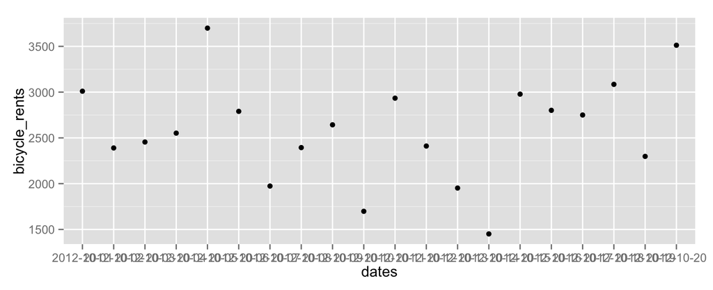

- But when we convert text as date

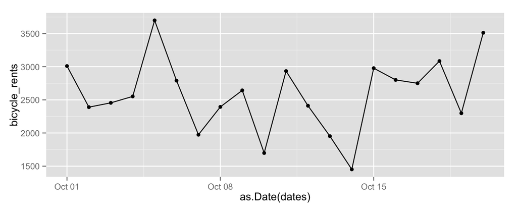

### Challenges to work with dates and times

- They look like numbers but they are not
  - special formats
  - leap years
  - different time zones
  - simple arithmetics does not work
- If you are not still scared enough think of day light saving time
  - how do you add/subtract an hour to a date on a moment of day light saving time
  - by the time you added an hour, they day light saving time may make it unchanged
- Dates and times are one of the most scary data types. If all the challenges are not handled correctly, all the analysis may be messed up.

### Working with dates conveniently

- Package `lubridate` by Garrett and Hadley

```r
# install.packages("lubridate")
library(lubridate)
```

- Base `R` functions may become unintuitive when dealing with dates
- `lubridate` made dates easier to handle
  - algebra with dates become intuitive
  - easy to remember

```r
ymd('1971-12-29')
```

```
[1] "1971-12-29 UTC"
```

```r
dmy(29121971)
```

```
[1] "1971-12-29 UTC"
```

### Parse text to date for use

- At first, parse characters to dates

| Functions | Descriptions |
| --- | --- |
| ymd() | year, month, day |
| ydm() | year, day, month |
| mdy() | month, day, year |
| dmy() | day, month, year |
| hm() | hour, minute |
| hms() | hour, minute, second |
| ymd_hms() | year, month, day, hour, minute, second |

- Example

```r
x <- ymd_hms('20141009 20:45:36')
x
```

```
[1] "2014-10-09 20:45:36 UTC"
```

- QUIZ: `weekdays(x) = ?`

| Functions | Descriptions |
| --- | --- |
| year() | Year |
| month() | Month |
| week() | Week |
| yday() | Day of year |
| mday() | Day of month |
| wday() | Day of week |
| hour() | Hour |
| minute() | Minute |
| second() | Second |
| tz() | Time zone |

- Once parsed, we can explore

```r
minute(x)
```

```
[1] 45
```

### Exploring dates

```r
date <- now()
month(date)
```

```
[1] 10
```

```r
month(date, label=TRUE)
```

```
[1] Oct
12 Levels: Jan < Feb < Mar < Apr < May < Jun < Jul < Aug < Sep < ... < Dec
```

```r
wday(date, label=TRUE, abbr=FALSE)
```

```
[1] Thursday
7 Levels: Sunday < Monday < Tuesday < Wednesday < Thursday < ... < Saturday
```

### Dates, times look simple !

- Not all the years are of same lengths
- Not all the months are of same lengths
- What about days, minutes and seconds ?
- How can we add or subtract or divide?
  - add 1 day to February 28
  - subtract 1 day from June 1
  - day difference from February 28 to June 1

```r
x <- mdy(02282012)
x
```

```
[1] "2012-02-28 UTC"
```

```r
x + days(1)
```

```
[1] "2012-02-29 UTC"
```

```r
y <- mdy(06012012)
y
```

```
[1] "2012-06-01 UTC"
```

```r
y - days(1)
```

```
[1] "2012-05-31 UTC"
```

```r
y - x
```

```
Time difference of 94 days
```

```r
xx <- x + years(1)
yy <- y + years(1)
yy - xx
```

```
Time difference of 93 days
```

### Time zone

```r
myTime <- ymd_hms('20141009 23:59:59')
nyTime <- force_tz(myTime, tz = "America/New_York")
nyTime
```

```
[1] "2014-10-09 23:59:59 EDT"
```

```r
chTime <- force_tz(myTime, tz = "America/Chicago")
chTime
```

```
[1] "2014-10-09 23:59:59 CDT"
```

- Same time but different time zones create differences

```r
nyTime - chTime
```

```
Time difference of -1 hours
```

### Date time algebra

```r
chTime
```

```
[1] "2014-10-09 23:59:59 CDT"
```

- Add one hour, one minute and one second to current time

```r
chTime + dhours(1) + dminutes(1) + dseconds(1)
```

```
[1] "2014-10-10 01:01:00 CDT"
```

- Add one year, one month and one day to Chicago time. **Notice** the time zone change. The daylight saving times are considered while doing the algebra.

```r
chTime + years(1) + months(1) + days(1)
```

```
[1] "2015-11-10 23:59:59 CST"
```

### Case Study: Boston hubway

[figure not shown]

### Case Study: when do Bostonians bike most?

- Boston hubway data
  - Saturday and Sunday make sense
  - why does Wednesday get crazy?

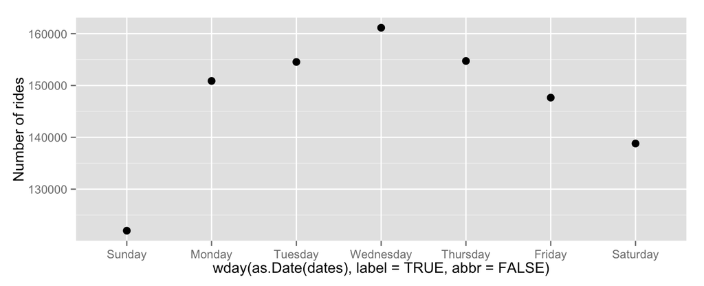

- Are the patterns for each of the days same? What plot should display that?

### Case study: Boston hubway data

- What are those peaks? Data does not know how to lie.

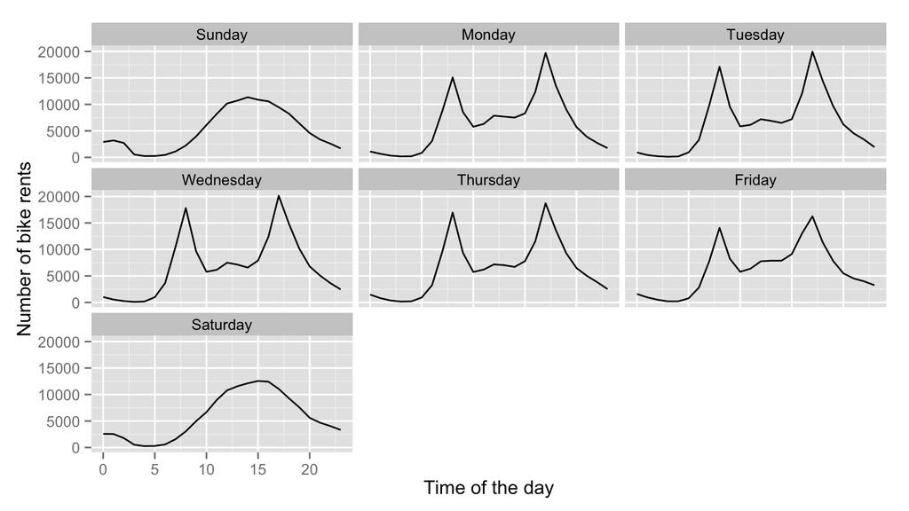

### Case study: Boston hubway data

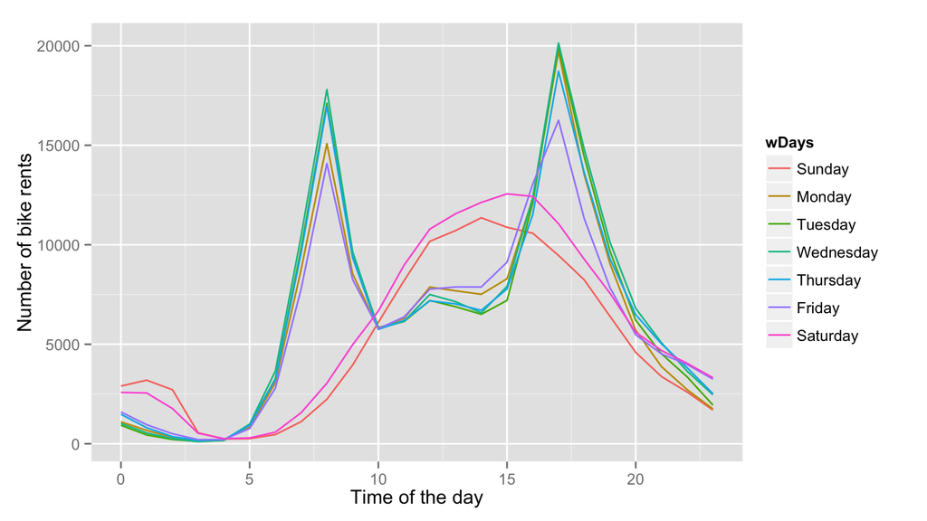

### Reading assignment and references

- Paper by Hadley Wickham on date  
  http://www.jstatsoft.org/v40/i03/paper
- To learn more on Boston Hubway data visualization and to get the data visit  
  http://hubwaydatachallenge.org/